# Exploration European Invertebrate Freshwater Data

Raya Keuth

16.04.2024

The here-investigated data was published in the following paper [Haase et al. 2023](https://www.nature.com/articles/s41586-023-06400-1#Sec24).

## Spatial coverage

In total data from these 22 countries is available:

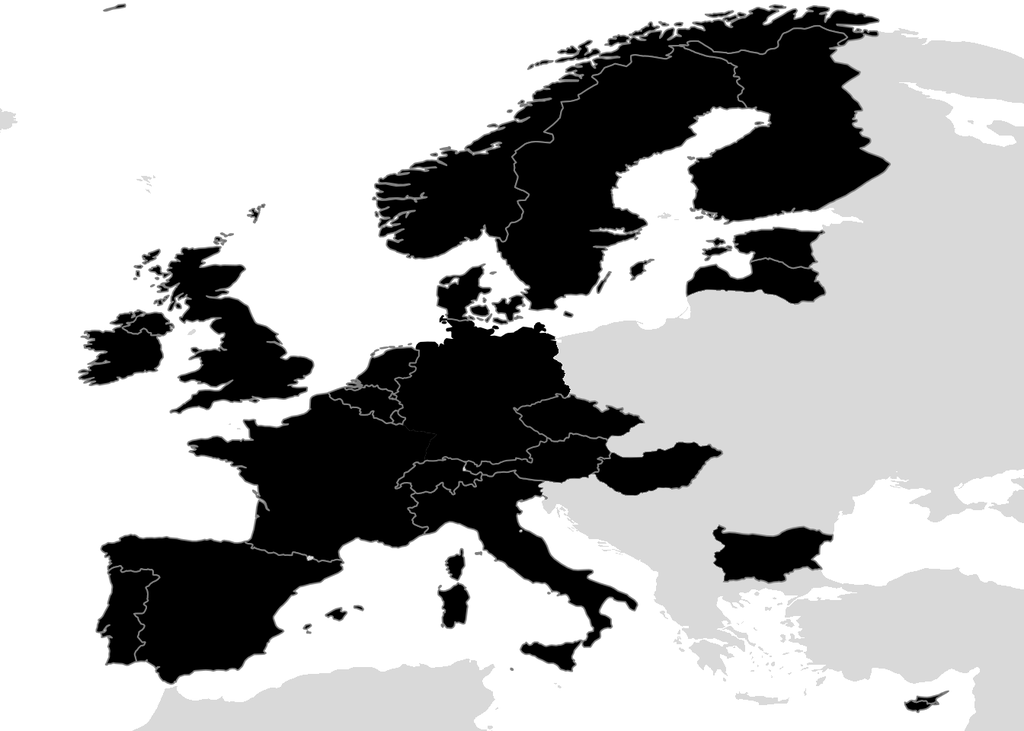

In total 1816 different study sites were sampled. The study sites are unevenly distributed between the countries:

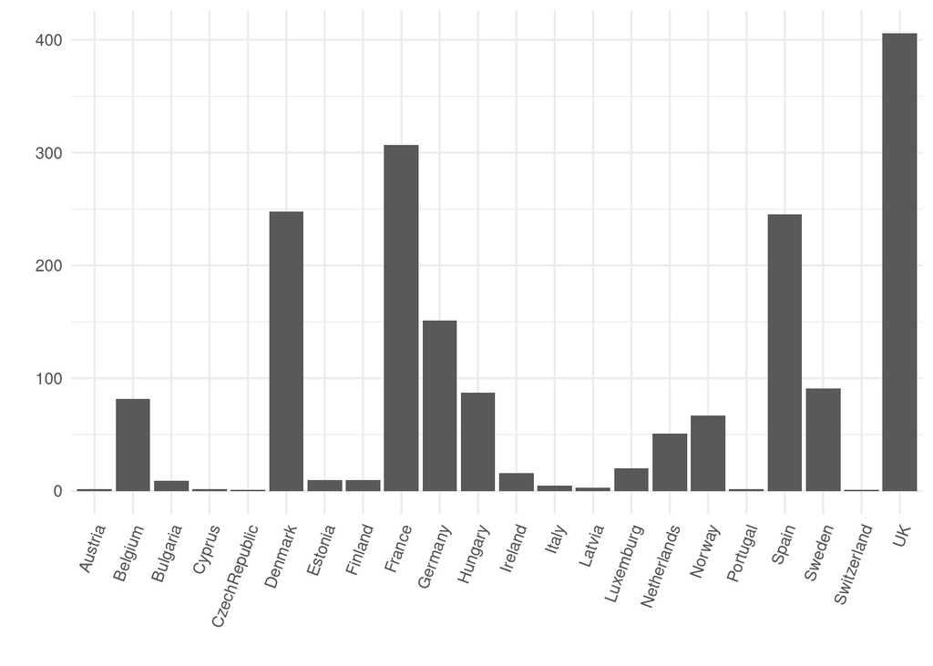

# Data exploration on the country level

## Number of records

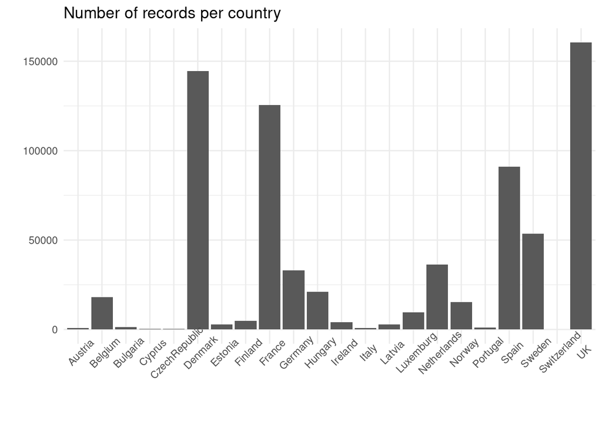

## Time coverage

The data set ranges from 1968 to 2020 (52 years). But not all years were sampled in every country:

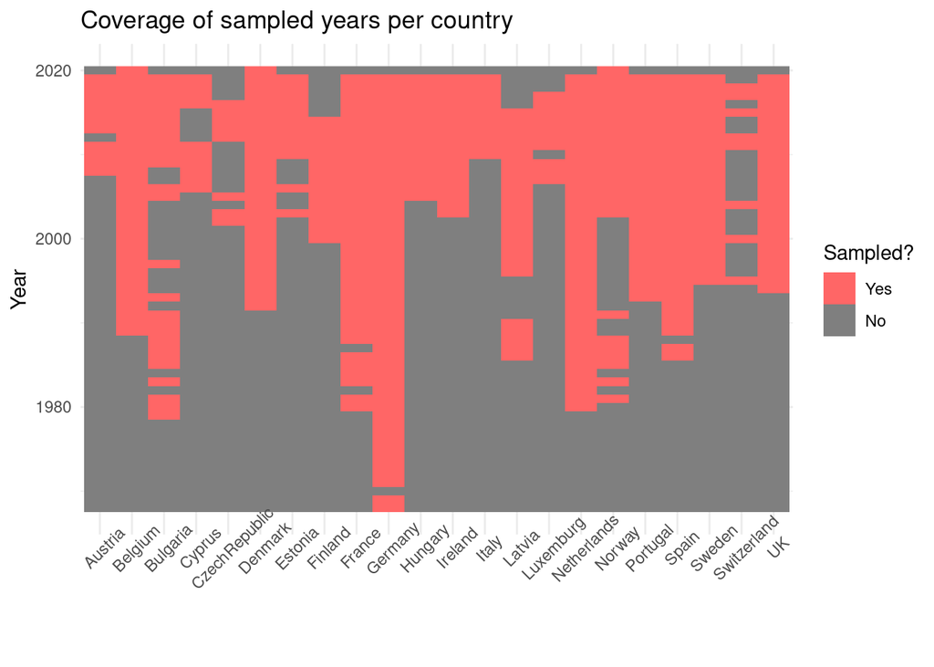

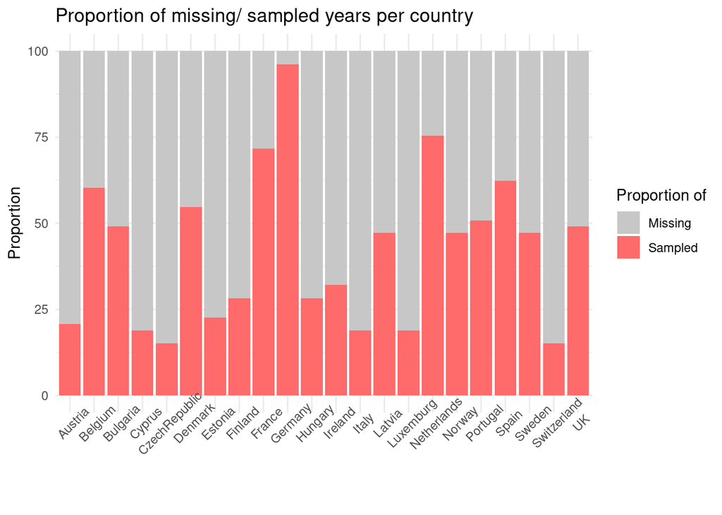

## Taxa coverage

In total 1391 species were found and 675 genus.

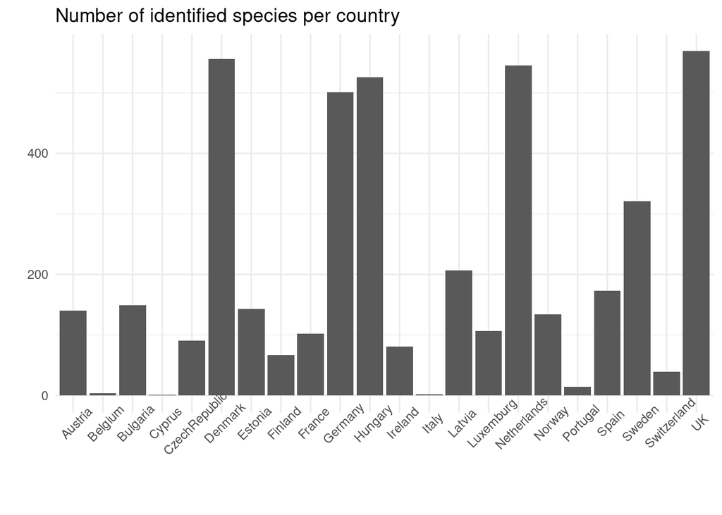

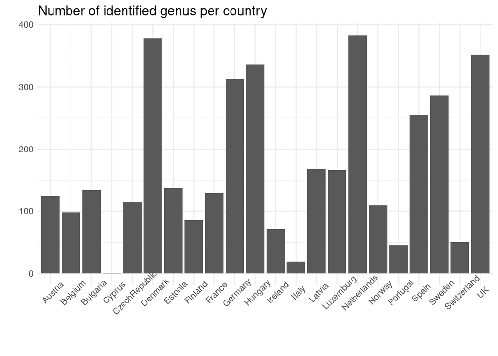

Proportion of individuals identified to a specific taxonomic level. “Coarser” means that the individual was identified to sub-family-level or coarser.

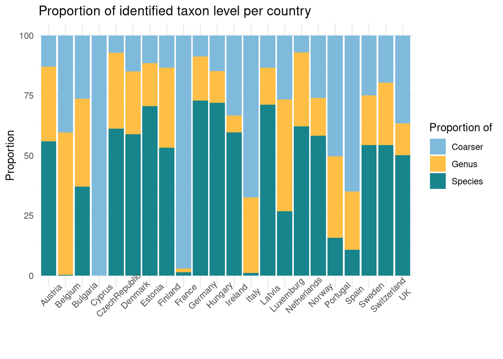

# Data exploration on the species level

The goal is to find a set of species which show a good spatial and temporal cover as well as several data points.

### Number of detections over all species

Each data point for this plot represents one species and its total number of detections over all countries and years.

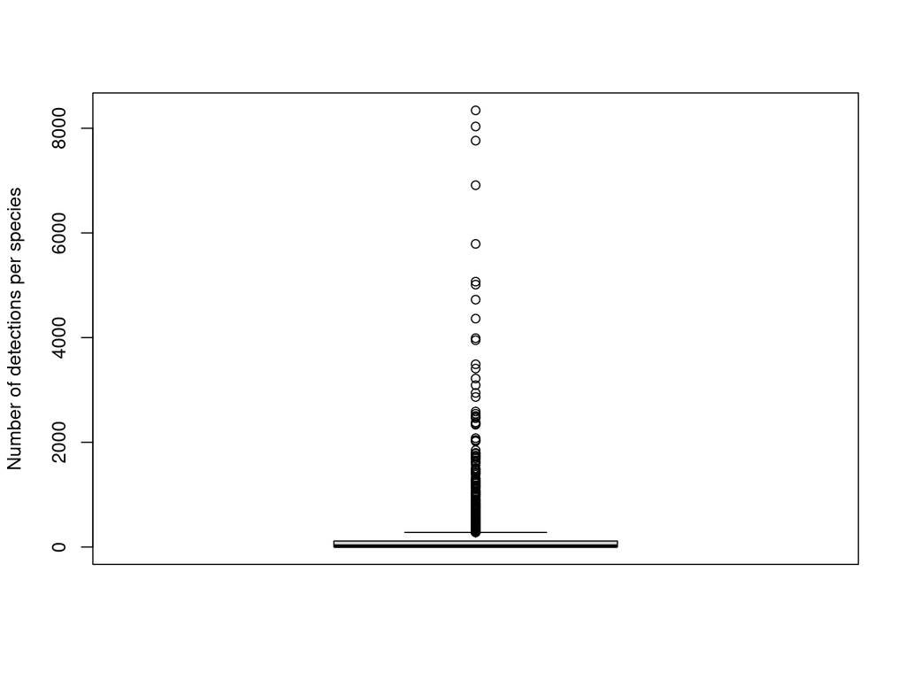

### Number of countries each species was found in (over all species)

Each data point again represents one species and the number of countries it was detected in. The total number of countries is 22.

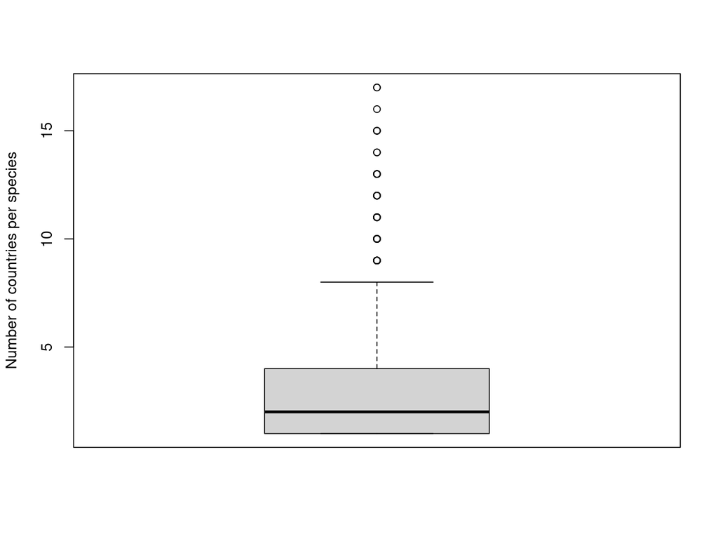

### Number of sampled years over all species

Each data point represents one species and its number of sampling years. However, this does not give information about completeness of the timeseries of each species. Total number of years is 52.

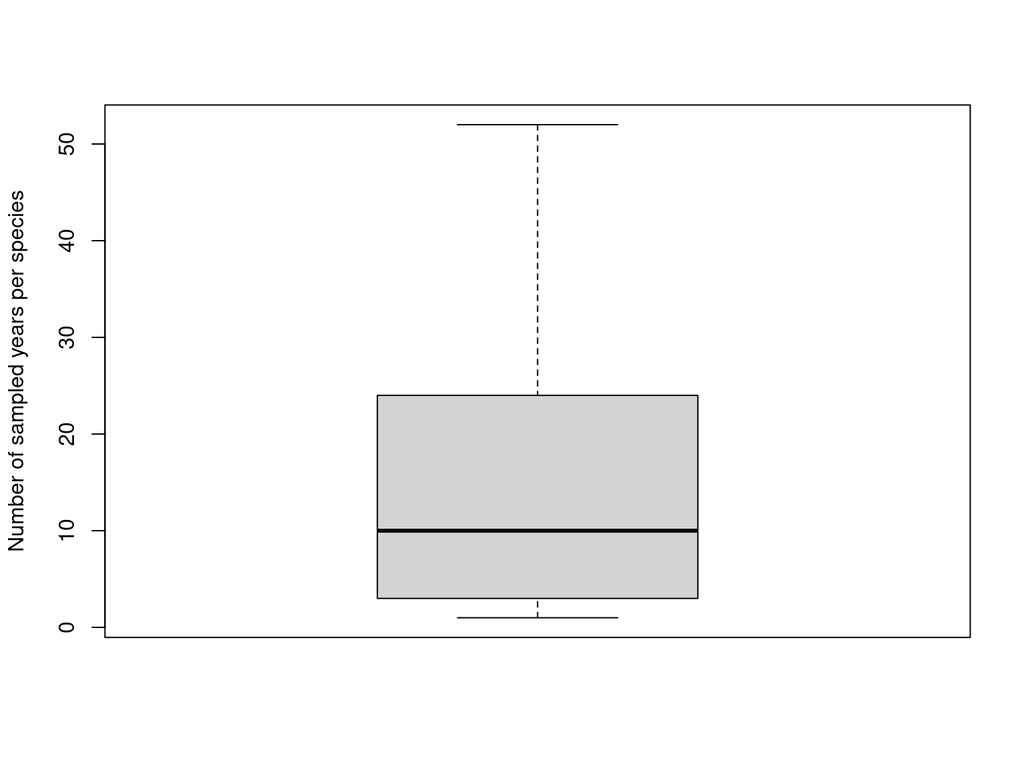